# Page title

## Coordinate Reference Systems

We’ll look at vector data today.

The geographic vector data model is based on points located within a coordinate reference system (CRS). Points can represent self-standing features (e.g., the location of a bus stop) or they can be linked together to form more complex geometries such as lines and polygons.

In this system London, for example, can be represented by the coordinates c(-0.1, 51.5). This means that its location is -0.1 degrees east and 51.5 degrees north of the origin. The origin in this case is at 0 degrees longitude (the Prime Meridian) and 0 degree latitude (the Equator) in a geographic (‘lon/lat’) CRS (Figure 2.1, left panel). The same point could also be approximated in a projected CRS with ‘Easting/Northing’ values of c(530000, 180000) in the British National Grid, meaning that London is located 530 km East and 180 km North of the origin of the CRS. This can be verified visually: slightly more than 5 ‘boxes’ — square areas bounded by the gray grid lines 100 km in width — separate the point representing London from the origin (Figure 2.1, right panel).

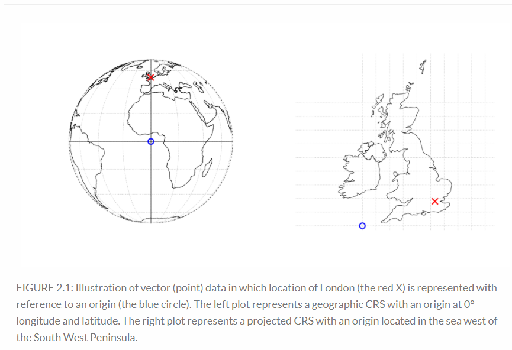

Let’s get started using some data

```r
# packages -------------------------------------------------------------
#install.packages("pacman")
pacman::p_load(dplyr,
               readxl,
               sf,
               tmap,
               ggplot2)
```

## Reading geospatial data

### Reading in Point / coordinate data

Let’s load some data. We’ll start with care homes data with information on coordinates for care homes in England ([data source without coordinates](https://www.cqc.org.uk/about-us/transparency/using-cqc-data)).

```r
# Read in data about ~15k UK care homes
care_homes <- readxl::read_excel("data/care_homes_df.xlsx", sheet = "input_carehomes")
```

```r
names(care_homes)
```

```
##  [1] "CQClocationid"   "locationname"    "locationodscode" "location_beds"
##  [5] "CQCrating"       "region"          "laname"          "city"
##  [9] "county"          "postcode"        "locationlat"     "locationlong"
```

### Reading in Shape files, geojsons

Geo files come in many shapes and forms. Have a look at the many download options for the [Regions boundaries file](https://geoportal.statistics.gov.uk/datasets/ons::regions-december-2020-en-bgc/about) for England.

For working in R, there is the amazing [sf package](https://r-spatial.github.io/sf/) that allows you to easily read, transform and save data with spatial elements. Let’s read a shaepfile with the function st_read (you could also use read_sf to read the file silently):

```r
# shapefile
# https://geoportal.statistics.gov.uk/datasets/ons::regions-december-2020-en-bgc/about

region_shape <- sf::st_read("data/Regions_(December_2020)_EN_BGC/Regions_(December_2020)_EN_BGC.shp")
names(region_shape)
```

```
##  [1] "OBJECTID"   "RGN20CD"    "RGN20NM"    "BNG_E"      "BNG_N"
##  [6] "LONG"       "LAT"        "Shape__Are" "Shape__Len" "geometry"
```

```r
head(region_shape)
```

```
## Simple feature collection with 6 features and 9 fields
## Geometry type: MULTIPOLYGON
## Dimension:     XY
## Bounding box:  xmin: 293941.4 ymin: 175098.2 xmax: 655653.8 ymax: 657536
## Projected CRS: OSGB 1936 / British National Grid
##   OBJECTID   RGN20CD                  RGN20NM  BNG_E  BNG_N      LONG      LAT
## 1        1 E12000001               North East 417314 600356 -1.728880 55.29701
## 2        2 E12000002               North West 350014 506279 -2.772390 54.44944
## 3        3 E12000003 Yorkshire and The Humber 446902 448736 -1.287140 53.93264
## 4        4 E12000004            East Midlands 477659 322635 -0.849690 52.79572
## 5        5 E12000005            West Midlands 386294 295477 -2.203580 52.55697
## 6        6 E12000006          East of England 571078 263235  0.504207 52.24073
##    Shape__Are Shape__Len                       geometry
## 1  8598909726    1003276 MULTIPOLYGON (((450272 5259...
## 2 14163659892    2266858 MULTIPOLYGON (((327828.6 37...
## 3 15408670452    1364889 MULTIPOLYGON (((495485.8 42...
## 4 15642227457    1821440 MULTIPOLYGON (((552995.1 32...
## 5 13003737884     921092 MULTIPOLYGON (((403387.8 36...
## 6 19130052498    3579312 MULTIPOLYGON (((570606.9 18...
```

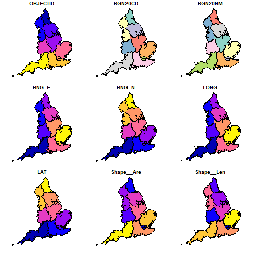

```r
plot(region_shape)
```

Let’s read a geojson file with the function st_read (again you could also use read_sf to read the file silently):

```r
# geojson format
# https://geoportal.statistics.gov.uk/datasets/ons::regions-december-2020-en-bgc/about

region_geojson <- sf::st_read("data/Regions_(December_2020)_EN_BGC.geojson")
names(region_geojson)
```

```
##  [1] "OBJECTID"      "RGN20CD"       "RGN20NM"       "BNG_E"
##  [5] "BNG_N"         "LONG"          "LAT"           "Shape__Area"
##  [9] "Shape__Length" "geometry"
```

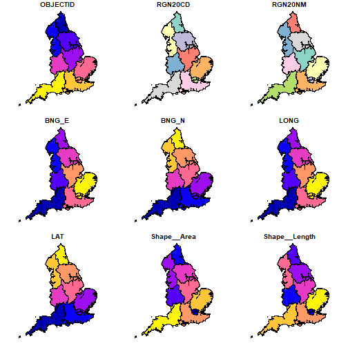

```r
plot(region_geojson)
```

### Choropleth map

Now that we know how to read in boundary files, let’s add some regional data to the regional shapes.

In a first step, let’s aggregate the care homes data to the level of the shapefile, so to the level of the English regions. We’re going to calculate the number of care homes and beds per region and then the percentage of good/outstanding care homes per region.

```r
# prep data at regional level
carehomes_by_region <- care_homes %>%  group_by(region) %>%
  summarise(number_carehomes = n(),
            number_beds = sum(location_beds, na.rm = T),
            num_good = sum(CQCrating =="Good", na.rm =T),
            num_outstanding = sum(CQCrating =="Outstanding", na.rm =T)
            ) %>%
  mutate(perc_good = num_good/number_carehomes,
         perc_outstanding = num_outstanding/number_carehomes)
```

Next we join the care home data onto the shapefile based on the common variable (i.e. the English region).

```r
region_shape_carehome <- region_shape %>%
  left_join(carehomes_by_region, by = c("RGN20NM" = "region"))
```

And voila, based on a shapefile and some data merged onto it, we can produce a meaningful map.

### Regional map

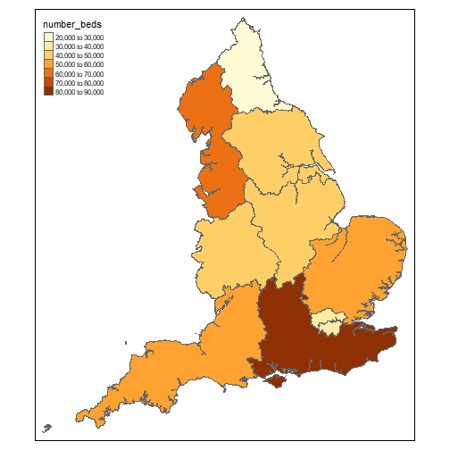

```r
# plot map
choropleth_map <- tmap::tm_shape(region_shape_carehome) +
  tmap::tm_polygons(col = "number_beds")

choropleth_map
```

Let’s do this again, add a bold title and move the legend outside.

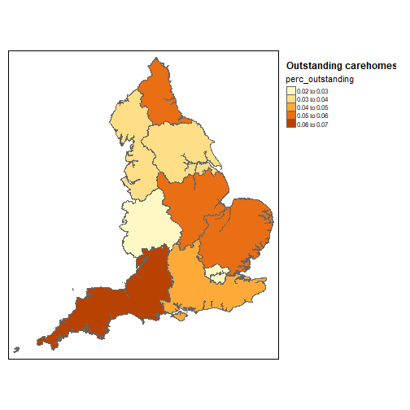

```r
#plot map

choropleth_map2 <- tmap::tm_shape(region_shape_carehome) +
  tmap::tm_polygons(col = "perc_outstanding") +
  tmap::tm_layout(legend.outside = TRUE, # move legend outside of box
            title= "Outstanding carehomes", # add title
            title.fontface = 2) # make title bold

choropleth_map2
```

This whole thing can also be done with ggplot - no need to use a mapping-specific package.

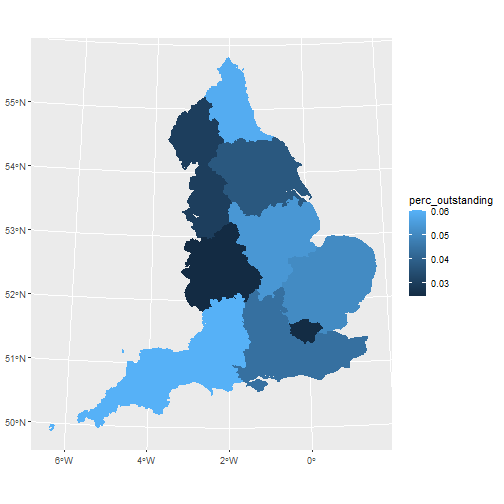

```r
# plot map
gg_choro <-ggplot(region_shape_carehome) +
  geom_sf(
    aes(
      geometry = geometry,
      fill = perc_outstanding,
      colour = perc_outstanding
    )
  )

gg_choro
```

In ggplot, we can apply the whole range of typical formatting we might like to use. This is probably a bit excessive, but you get the point: there is lots of flexibility in formatting your map.

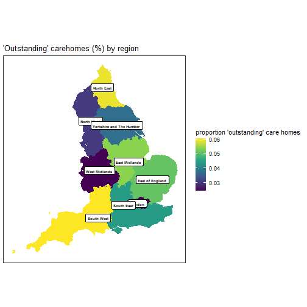

```r
gg_choro +
  coord_sf(datum = NA) + # removes the grid lines
  ggtitle("'Outstanding' carehomes (%) by region") + # adds title
  theme_bw()+
  scale_fill_viridis_c("proportion 'outstanding' care homes") +
  scale_colour_viridis_c("proportion 'outstanding' care homes")+
  theme(axis.title.x = element_blank(), # removes axis label
        axis.title.y = element_blank()) + # removes axis label
  # To remove the box use: panel.border=element_blank()
  geom_sf_label(aes(label = RGN20NM), size = 2, fontface = "bold") # add labels per region
```

## Writing out / saving spatial data

What if we want to save the object region_shape_carehome that currently holds both the boundary information and the aggregated care homes data? If we want to preserve the spatial information it’s best to save the output as a spatial file. This saves you from clunkily converting a csv file with a geometry character column back into a spatial object (it’s possible but it’s an unnecessary headache). Let’s look at the object:

```r
region_shape_carehome
```

```
## Simple feature collection with 9 features and 15 fields
## Geometry type: MULTIPOLYGON
## Dimension:     XY
## Bounding box:  xmin: 82668.52 ymin: 5352.6 xmax: 655653.8 ymax: 657536
## Projected CRS: OSGB 1936 / British National Grid
##   OBJECTID   RGN20CD                  RGN20NM  BNG_E  BNG_N      LONG      LAT
## 1        1 E12000001               North East 417314 600356 -1.728880 55.29701
## 2        2 E12000002               North West 350014 506279 -2.772390 54.44944
## 3        3 E12000003 Yorkshire and The Humber 446902 448736 -1.287140 53.93264
## 4        4 E12000004            East Midlands 477659 322635 -0.849690 52.79572
## 5        5 E12000005            West Midlands 386294 295477 -2.203580 52.55697
## 6        6 E12000006          East of England 571078 263235  0.504207 52.24073
## 7        7 E12000007                   London 517515 178392 -0.308660 51.49227
## 8        8 E12000008               South East 470062 172924 -0.993110 51.45097
## 9        9 E12000009               South West 285013 102567 -3.633460 50.81119
```

[output cut: 20 more lines]

And now let’s save it in a way so that we can easily read it back in when we need it. Writing out is as simple as using the function st_write and as part of the file path specifying an extension like ‘geojson’ or ‘shp’ (note that if you choose shape files, you need to keep all outputted files - it looks like R only needs one, but the other ones are actually needed, too).

```r
sf::st_write(region_shape_carehome, "data/region_shapes_with_aggregated_carehome_data.geojson")
```

```
## Writing layer `region_shapes_with_aggregated_carehome_data' to data source
##   `data/region_shapes_with_aggregated_carehome_data.geojson' using driver `GeoJSON'
## Writing 9 features with 15 fields and geometry type Multi Polygon.
```

```r
# #reading the file in late on would then be:
# regional_carehome_data_with_boundaries <- sf::st_read("data/region_shapes_with_aggregated_carehome_data.geojson")
```

## Exercise

Using [NHS England Regions](https://data.gov.uk/dataset/7514fa81-a0c2-4031-9c20-63be72cc24c2/nhs-england-regions-april-2020-boundaries-en-bfc) boundaries and data on [covid hospitalCases by NHS Region](https://coronavirus.data.gov.uk/details/download), produce a choropleth map for case number on Nov 9th 2021. If you are downloading the data straight from the web: 1. Choose geojson or shapefile format for the NHS regions. 2. Choose areaType = nhsRegion and metric = hospitalCases and format=csv for the covid data.

## Point data

This all works fine if we link on shared non-geospatial variables like region name or LAD code (where the region name of LAD code is present in both data sets). It gets more tricky when we want to link based on geometry.

How can we link based on geometry? Let’s plot the care home coordinates:

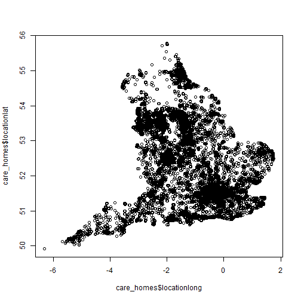

```r
plot(care_homes$locationlong, care_homes$locationlat)
```

and let’s add them to our existing map of English regions:

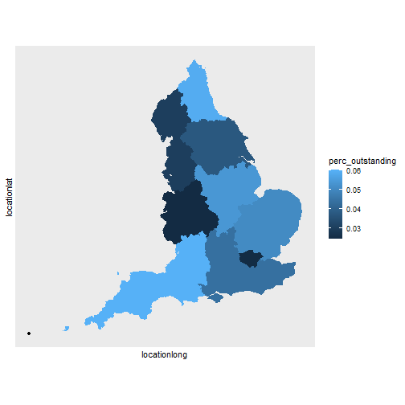

```r
gg_choro +
  coord_sf(datum = NA) + # removes the grid lines
  geom_point(data = care_homes, aes(x = locationlong, y = locationlat),
             alpha = 0.5)
```

Any ideas where all the points have gone (well, there is one, but it looks like an unlikely location for a care home)?

We’ll come back to this soon…

### From coordinate columns to spatial object

When trying to combine different bits of geometry, it’s best to convert all parts into the same type of object, i.e. spatial objects, to avoid reduce confusion around linking them up.

We can turn the care home data into a spatial object by defining a coordinate reference system alongside the given coordinates. For anyone who wants to dive in deep into CRS, check out this [Guide to Coordinate Systems in Great Britain] (https://www.ordnancesurvey.co.uk/documents/resources/guide-coordinate-systems-great-britain.pdf).

All you need to know for now (and for most of your work situations probably) are these two EPSG codes for commonly used CRSs:

- Latitude/Longitude (WGS84) - EPSG code: 4326
- British National Grid - EPSG:27700

A little reminder of what’s in our data right now…

```r
names(care_homes)
```

```
##  [1] "CQClocationid"   "locationname"    "locationodscode" "location_beds"
##  [5] "CQCrating"       "region"          "laname"          "city"
##  [9] "county"          "postcode"        "locationlat"     "locationlong"
```

… this suggests that we have latitude /longitude data, so will need to specify the CRS using the code “4326”. To do so we use the function st_as_sf that convert foreign objects to sf objects.

```r
# Before transforming any rows without geometry inforamtion have to be removed
# So how many care homes have no coordinate data?
sum(is.na(care_homes$locationlat)|is.na(care_homes$locationlong))
```

```
## [1] 3
```

```r
# Set CRS
carehomes_sf <- sf::st_as_sf(care_homes %>%
                               # let's remove those without coordinate data for further analysis
                               filter(!(is.na(care_homes$locationlat)|is.na(care_homes$locationlong))),
                             coords = c("locationlat", "locationlong"),
                             crs = 4326)
```

```r
names(carehomes_sf)
```

```
##  [1] "CQClocationid"   "locationname"    "locationodscode" "location_beds"
##  [5] "CQCrating"       "region"          "laname"          "city"
##  [9] "county"          "postcode"        "geometry"
```

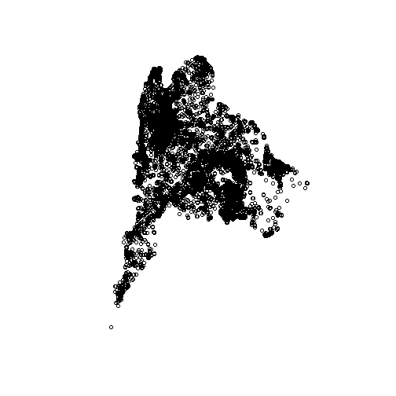

```r
# The first step is always a plot
plot(carehomes_sf$geometry)
```

That looks odd. I always confuse which comes first longitude or latitude! Let’s turn this around: x = long and y = lat. Let’s try again:

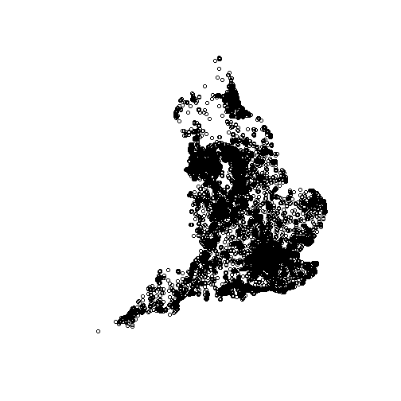

```r
carehomes_sf <- sf::st_as_sf(care_homes %>%
                               filter(!(is.na(care_homes$locationlat)|is.na(care_homes$locationlong))),
                             coords = c("locationlong", "locationlat"),
                             crs = 4326) # alternatively, crs can be set with a Proj4 string
plot(carehomes_sf$geometry)
```

This looks better. Let’s try and combine the two (i.e. the shapefile and the care home points).

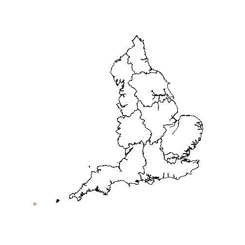

```r
plot(region_shape_carehome$geometry)

plot(carehomes_sf$geometry, add= TRUE , col = 'red')
```

and here we are again. A single point somewhere in the ocean…

Let’s have a look at which CRS is associated with the region boundary file:

```r
names(region_shape_carehome)
```

```
##  [1] "OBJECTID"         "RGN20CD"          "RGN20NM"          "BNG_E"
##  [5] "BNG_N"            "LONG"             "LAT"              "Shape__Are"
##  [9] "Shape__Len"       "number_carehomes" "number_beds"      "num_good"
## [13] "num_outstanding"  "perc_good"        "perc_outstanding" "geometry"
```

Looking at the column names is not sufficient this time. We have both BNG_E/BNG_N and also LONG/LAT columns, so need to find out which of them the geometry column is based on. To find an object’s CRS, we use the st_crs function:

### Coordinate Reference Systems

```r
#sf::st_crs(carehomes_sf)
sf::st_crs(region_shape_carehome)
```

```
## Coordinate Reference System:
##   User input: OSGB 1936 / British National Grid
##   wkt:
## PROJCRS["OSGB 1936 / British National Grid",
##     BASEGEOGCRS["OSGB 1936",
##         DATUM["OSGB 1936",
##             ELLIPSOID["Airy 1830",6377563.396,299.3249646,
##                 LENGTHUNIT["metre",1]]],
##         PRIMEM["Greenwich",0,
##             ANGLEUNIT["degree",0.0174532925199433]],
##         ID["EPSG",4277]],
##     CONVERSION["British National Grid",
##         METHOD["Transverse Mercator",
##             ID["EPSG",9807]],
##         PARAMETER["Latitude of natural origin",49,
##             ANGLEUNIT["degree",0.0174532925199433],
##             ID["EPSG",8801]],
##         PARAMETER["Longitude of natural origin",-2,
##             ANGLEUNIT["degree",0.0174532925199433],
##             ID["EPSG",8802]],
##         PARAMETER["Scale factor at natural origin",0.9996012717,
##             SCALEUNIT["unity",1],
##             ID["EPSG",8805]],
##         PARAMETER["False easting",400000,
##             LENGTHUNIT["metre",1],
##             ID["EPSG",8806]],
##         PARAMETER["False northing",-100000,
##             LENGTHUNIT["metre",1],
##             ID["EPSG",8807]]],
##     CS[Cartesian,2],
##         AXIS["(E)",east,
##             ORDER[1],
##             LENGTHUNIT["metre",1]],
##         AXIS["(N)",north,
##             ORDER[2],
##             LENGTHUNIT["metre",1]],
##     USAGE[
##         SCOPE["Engineering survey, topographic mapping."],
##         AREA["United Kingdom (UK) - offshore to boundary of UKCS within 49Â°45'N to 61Â°N and 9Â°W to 2Â°E; onshore Great Britain (England, Wales and Scotland). Isle of Man onshore."],
##         BBOX[49.75,-9,61.01,2.01]],
##     ID["EPSG",27700]]
```

Remember this? :)

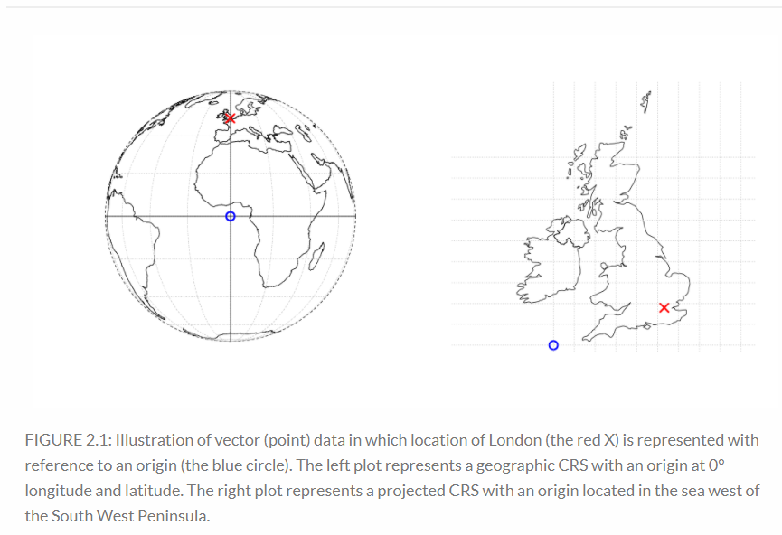

So we need to transform the CRS of one part of the data to match the other one. For this we use the st_transform function:

```r
carehomes_bng <- sf::st_transform(carehomes_sf, crs = sf:: st_crs(region_shape_carehome))

#sf::st_crs(carehomes_bng)
```

```r
sf::st_crs(carehomes_bng) == sf::st_crs(region_shape_carehome)
```

```
## [1] TRUE
```

### Plotting shapes and points together

Now we can plot the points on top of the region polygons:

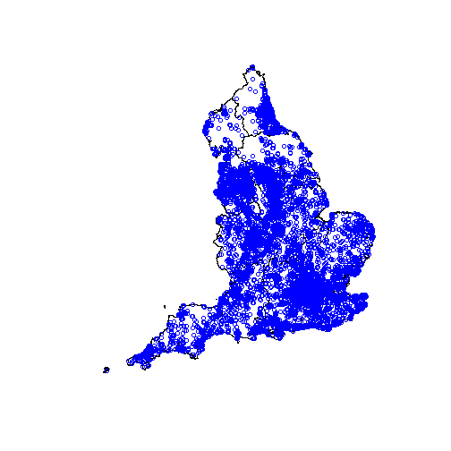

```r
plot(region_shape_carehome$geometry)

plot(carehomes_bng$geometry, add= TRUE , col = 'blue')
```

```r
#plot(carehomes_bng %>% filter(CQCrating=="Inadequate") %>% pull(geometry), add= TRUE , col = 'red')
```

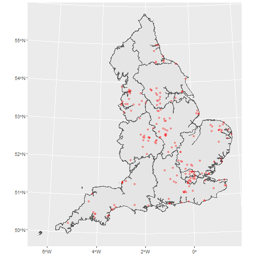

```r
# plot map

ggplot() +
  geom_sf(data = region_shape_carehome
  ) +
  geom_sf(data = carehomes_bng$geometry[carehomes_bng$CQCrating=="Inadequate"], colour ="red",
          alpha = 0.3)
```

## Interacticve maps: zooming & pop-up labels

Check out the [Leaflet Cheat Sheet](https://ugoproto.github.io/ugo_r_doc/pdf/leaflet-cheat-sheet.pdf).

```r
# Create a leaflet map with default map tile using addTiles()
# add markers using functions like addMarkers / addCircleMarkers/ ...

# some of the mapping is easier when we have long/lat coordinates, so let's get them back:
carehomes_sf <- carehomes_sf %>%
  mutate(locationlong = unlist(purrr::map(geometry,1)),
         locationlat = unlist(purrr::map(geometry,2)))

carehomes_sf %>%
  filter(CQCrating=="Inadequate") %>%
  leaflet::leaflet() %>%
  leaflet::addTiles() %>%
  leaflet::addMarkers(
    lng = ~locationlong,
    lat = ~locationlat
  )
```

[interactive chart not shown]

```r
# set a View and Zoom focused on any location
# apply some html to format labels and popups

# define a marker for my awesome location
icons <- leaflet::awesomeIcons(
  icon = 'ios-close',
  iconColor = 'black',
  library = 'ion',
  markerColor = 'red'
)

carehomes_sf %>%
  filter(CQCrating=="Outstanding") %>%
  leaflet::leaflet() %>%
  leaflet::addTiles() %>%
  leaflet::addMarkers(
    lng = ~locationlong,
    lat = ~locationlat,
    popup = ~paste0("<b>", locationname, "</b>", "<br/>",
                    "No. of beds: ", location_beds),
    label = ~locationname) %>%
  leaflet::addAwesomeMarkers(lng = -1.5346255, lat = 53.7987595,
                             label = paste0("DHSC Leeds: No beds available"),
                             icon = icons) %>%
  leaflet::setView(lng = -1.5346255, lat = 53.7987595, zoom = 12)
```

[interactive chart not shown]

You can go even more exotic and do colour coding depending on values in your data frame:

```r
# Create a continuous palette function
col_pal <- leaflet::colorFactor(
  palette = c("yellow", # good
              "red", # I
              "grey", # no evidence
              "green", # outstanding
              "orange" # RI
              ),
  domain = carehomes_sf$CQCrating)

# Let's focus on a smaller region only and add some colour
carehomes_sf %>%
  filter(laname == "Cumbria") %>%
  leaflet::leaflet() %>%
  leaflet::addTiles() %>%
  leaflet::addCircleMarkers(lng = ~locationlong,
             lat = ~locationlat ,
             popup = ~paste0("<b>", locationname, "</b>", "<br/>",
                             "CQC rating: ", CQCrating, "<br/>",
                             "No. of beds: ", location_beds),
             label = ~locationname,
             color = ~col_pal(CQCrating)
  ) %>%
  leaflet::addAwesomeMarkers(lng =  -3.134706, lat = 54.601276,
                             label = paste0("Keswick centre"))
```

[interactive chart not shown]

How to save a leaflet map? Using the saveWidget function from the htmlwidgets package:

```r
# store map as an object (this is simply repeat code from above)
outstanding_care_home_map_DHSC <- carehomes_sf %>%
  filter(CQCrating=="Outstanding") %>%
  leaflet::leaflet() %>%
  leaflet::addTiles() %>%
  leaflet::addMarkers(
    lng = ~locationlong,
    lat = ~locationlat,
    popup = ~paste0("<b>", locationname, "</b>", "<br/>",
                    "No. of beds: ", location_beds),
    label = ~locationname) %>%
  leaflet::addAwesomeMarkers(lng = -1.5346255, lat = 53.7987595,
                             label = paste0("DHSC Leeds: No beds available"),
                             icon = icons) %>%
  leaflet::setView(lng = -1.5346255, lat = 53.7987595, zoom = 12)

# save as html
htmlwidgets::saveWidget(outstanding_care_home_map_DHSC, "outputs/outstanding_care_home_map_DHSC.html")
```

## Exercise

Using [NHS Hospital data](https://www.nhs.uk/about-us/nhs-website-datasets/),

1. transform the data into a spatial data object with a geometry column
2. extract lat and long coordinates and save them as separate column in your spatial data frame
3. produce a leaflet map of hospitals in your city or a city near you (I recommend filtering the data by “City” because leaflet can get stuck when processing lots of data at once) and add an awesome marker at a location of your choosing.
4. check the CRS and change the CRS to BNG

## Further geo infos to explore

First of all, I’d like to again recommend this great source for [Geocomputation with R](https://geocompr.robinlovelace.net/index.html).

Acronym info: EPSG = European Petroleum Survey Group

Translation between different types of map file (Shape files, TAB, etc) Easiest would be to write out the file within Mapinfo as a MapInfo Interchange (*.mif) file. Then you can use this approach to [reading a mid files](https://gist.github.com/Robinlovelace/29d387f6b48fd9bf9d2d).

Other shape files you might need: * [Clinical Commissioning Groups (CCGs)](https://data.gov.uk/dataset/ae8c408b-f645-4982-b934-a9c8a7788eb0/clinical-commissioning-groups-april-2020-full-extent-boundaries-en) * [NHS England Regions](https://data.gov.uk/dataset/7514fa81-a0c2-4031-9c20-63be72cc24c2/nhs-england-regions-april-2020-boundaries-en-bfc) * [Local Authority Districts](https://geoportal.statistics.gov.uk/datasets/ons::local-authority-districts-may-2021-uk-bfc/about)

Interesting geo data [NHS provider data](https://www.nhs.uk/about-us/nhs-website-datasets/), e.g. about hospitals or GPs. Make sure you open and save the data in line with the [NHS data download guidance](https://assets.nhs.uk/prod/documents/NHS-Website-about-our-data-downloads.pdf) using excel before reading it into R.

Background mapping Through the Public Sector Geospatial Agreement, we have access to a whole range of accurate, detailed background maps from Ordnance Survey that can conveniently be accessed through the [OS Maps API](https://osdatahub.os.uk/docs/wmts/overview?_ga=2.213849623.24761062.1635962454-391988200.1635870638).

Travel time analysis As a starting point for travel time analysis, feel free to use and adapt the code from my [Coffee & Coding session](https://github.com/DataS-DHSC/coffee-and-coding/tree/master/2021-10-21%20Using%20google%20maps%20distance%20matrix%20api) on using the google maps distance matrix API for calculating driving distances and driving times. This can be adapted for walking or public transport mode.